# Better Practices for Effective Data Exploration

# Data Visualization Guideline 4: Integrate the Graphics and Text

1. Remove legends when possible and label data directly
2. Write an active title like a newspaper headline
3. Add explainers

`labs()` adds title, subtitle, caption, and tag to ggplot2 objects. It can also be used to overwrite x, y, and legend titles. Use NULL to remove a label entirely (not `""`).

Titanic Example (ctn)

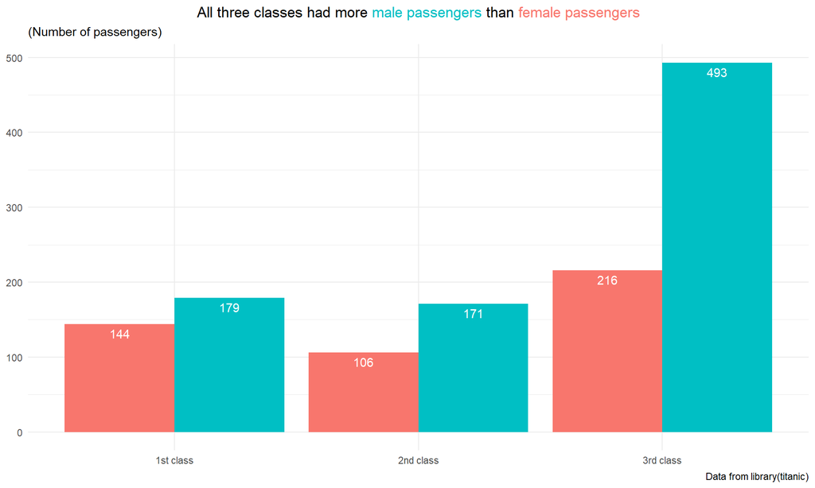

```r
library(ggtext)

ggplot(titanic, aes(x = Class, y = n, fill = Sex)) +
  geom_col(position = "dodge") +
  scale_y_continuous(breaks = seq(0, 800, 100)) +
  geom_text(aes(label = n), vjust = 1.5,
            position = position_dodge(.9),
            color = "white") +
  labs(title = "All three classes had more <span style = 'color:#00BFC4;'>male passengers</span> than <span style = 'color:#F8766D;'>female passengers</span>",
    subtitle = "(Number of passengers)",
    caption = "Data from library(titanic)",
    x = NULL,
    y = NULL
  ) +
  theme_minimal() +
  theme(plot.title = element_markdown(hjust = 0.5)) +
  guides(fill = "none")
```

# Data Visualization Guideline 5: Start with Gray

> “Whenever you make a graph, start with all gray data elements. By doing so, you force yourself to be purposeful and strategic in your use of color, labels, and other elements.”

[`library(gghighlight)`](https://cran.r-project.org/web/packages/gghighlight/vignettes/gghighlight.html) complements this idea of starting with gray.

Cumulative Expenditure Example

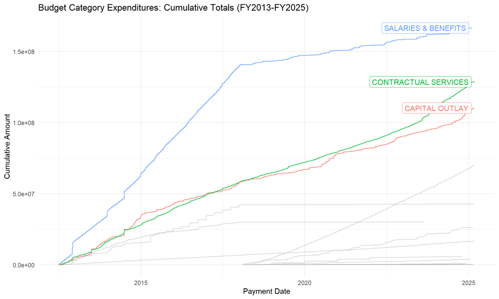

# Data Visualization Guideline 5 Continue – steps for generating the previous plot

Step 1: Compute the cumulative sum of amount over the years.

```r
OE.cumsum <- OE %>%
  mutate(budget_category = ifelse(budget_category == "INTERFUND & TFR OUT",
                                  "INTERFUND & TFRS OUT", budget_category),
         budget_category = ifelse(budget_category == "CONTRACTUAL SERVCS",
                                  "CONTRACTUAL SERVICES", budget_category)) %>%
  arrange(payment_date, budget_category) %>%
  group_by(budget_category) %>%
  mutate(cumsum = cumsum(amount))
```

Step 2: Create a line plot with `x = payment_date`, `y = cumsum`, `group = budget_category`, and geom_line()

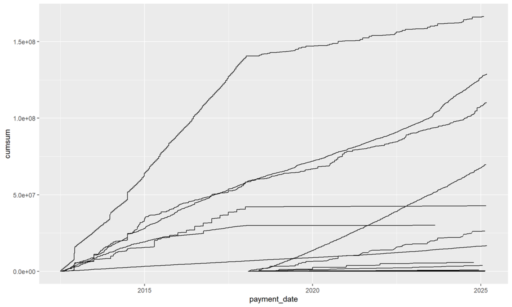

```r
OE.cumsum %>%
  ggplot(aes(payment_date, cumsum, group = budget_category))+
  geom_line()
```

**Note:** If we simply create a line graph with `color = budget_category`, then

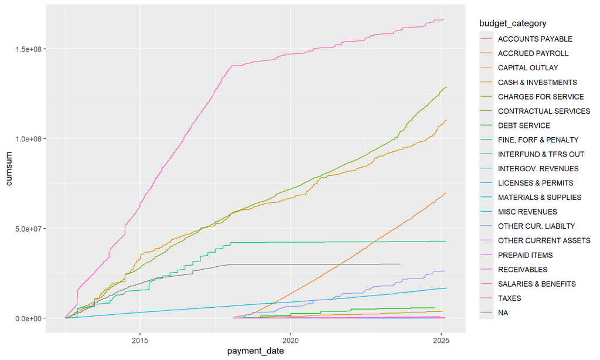

```r
OE.cumsum %>%
  ggplot(aes(payment_date, cumsum, color = budget_category))+
  geom_line()
```

Step 3: Add the following code to clean up the x-axis and y-axis.

```r
labs(x = "Payment Date",
     y = "Cumulative Amount",
     title = "Budget Category Expenditures: Cumulative Totals (FY2013-FY2025)")
```

Step 4: Suppose we want to highlight the three budget categories with the highest amounts. We can use library(gghighlight). Switch *group* to *color* in your existing code and add `gghighlight(max(cumsum) > 75000000)`.

Step 5: Above the data viz, add `theme_minimal()`. Or run `theme_set(theme_minimal())`, which changes the default theme for the entire R session.

Put everything together.

```r
library(gghighlight)

OE %>%
  mutate(budget_category = ifelse(budget_category == "INTERFUND & TFR OUT",
                                  "INTERFUND & TFRS OUT", budget_category),
         budget_category = ifelse(budget_category == "CONTRACTUAL SERVCS",
                                  "CONTRACTUAL SERVICES", budget_category)) %>%
  arrange(payment_date, budget_category) %>%
  group_by(budget_category) %>%
  mutate(cumsum = cumsum(amount)) %>%
  ggplot(aes(payment_date, cumsum, color=budget_category,
             group=budget_category))+
  geom_line()+
  labs(x = "Payment Date",
     y = "Cumulative Amount",
     title = "Budget Category Expenditures: Cumulative Totals (FY2013-FY2025)")+
  gghighlight(max(cumsum) > 75000000)+
  theme_minimal()
```

# Time Series Plots

Standard ACF/PACF plots require evenly spaced time intervals. For irregularly spaced data like `payment_date`, we can create regular time bins (e.g., using `fiscal_year` and `fiscal_year_period`) before analysis.

- Create `combined` = `fiscal_year`-`fiscal_year_period` pattern

```r
OE <- OE %>%
  mutate(combined = paste(fiscal_year,
                          sprintf("%02d", fiscal_year_period), sep = "-")) %>%
  arrange(combined)
```

### Time Series Plot

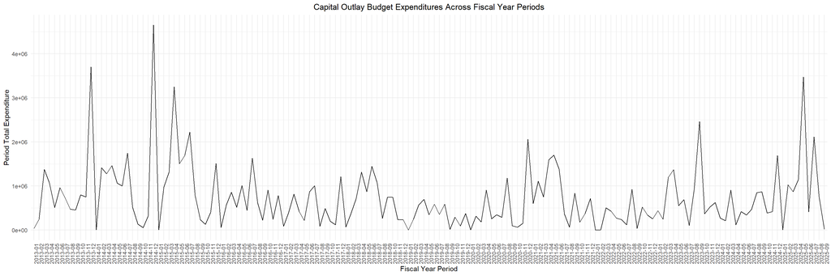

```r
OE %>%
  filter(budget_category %in% c("CAPITAL OUTLAY")) %>%
  group_by(combined, budget_category) %>%
  summarise(periodtotal = sum(amount)) %>%
  arrange(combined, budget_category) %>%
  ggplot(aes(x = combined, y = periodtotal, group = budget_category))+
  geom_line()+
  labs(x = "Fiscal Year Period",
       y = "Period Total Expenditure",
       title = "Capital Outlay Budget Expenditures Across Fiscal Year Periods")+
  theme_minimal()+
  theme(axis.text.x = element_text(angle = 90, hjust = 1),
        plot.title = element_text(hjust = 0.5))
```

### ACF

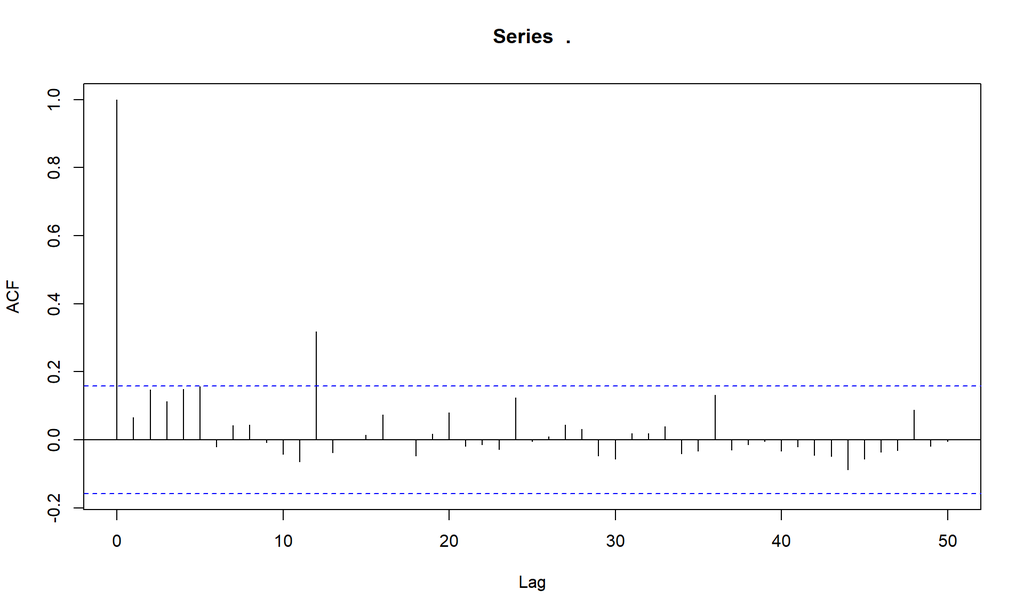

```r
OE %>%
  filter(budget_category %in% c("CAPITAL OUTLAY")) %>%
  group_by(combined, budget_category) %>%
  summarise(periodtotal = sum(amount)) %>%
  arrange(combined, budget_category) %>%
  pull(periodtotal) %>%
  acf(lag.max = 50)
```

### PACF

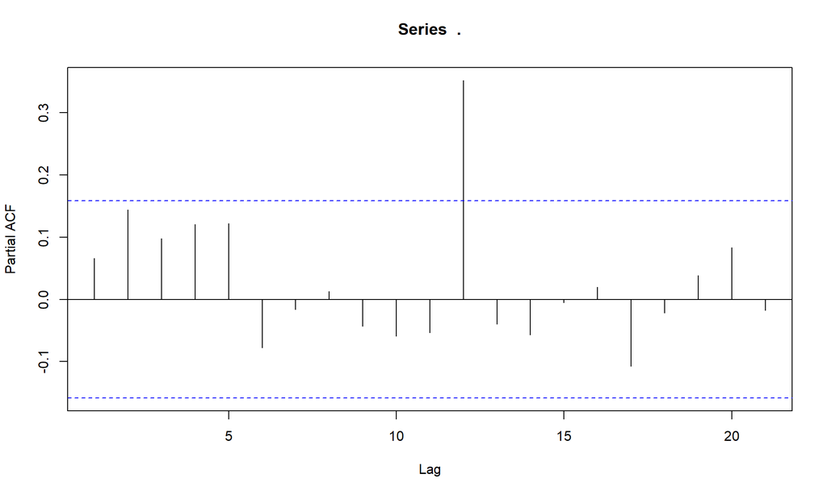

```r
OE %>%
  filter(budget_category %in% c("CAPITAL OUTLAY")) %>%
  group_by(combined, budget_category) %>%
  summarise(periodtotal = sum(amount)) %>%
  arrange(combined, budget_category) %>%
  pull(periodtotal) %>%
  pacf()
```

The ACF or PACF plot at lag 12 is outside of the confidence interval (blue dashed lines), it indicates a significant correlation at lag 12 (i.e. strong yearly seasonal effect with 12 months = 1 year).

# Main Takeaways

- Check the missing values
- Choose the right charts and graphs for the job. Show the information clearly is the key!
- Avoid the spaghetti chart by faceting or using small multiples.
- Reduce the clutter and avoid 3D plots!
- Integrate the graphics and text in a smart and seamless manner.
- Start with gray, start from simple.

# Resources

### Major Recources

- https://github.com/awunderground/sdss2021_data-viz-training
- By Aaron Williams, Senior Data Scientist at the Urban Institute

### Rstudio Cheatsheets

- https://www.rstudio.com/resources/cheatsheets/

### Reference Books

#### Free online books with excellent material

- R for Data Science: https://r4ds.had.co.nz/index.html
- Hands-on Programming with R: https://rstudio-education.github.io/hopr/
- R Graphics Cookbook: https://r-graphics.org/
- Fundamentals of Data Visualization: https://clauswilke.com/dataviz/

#### Other books

- Better Data Visualizations: A Guide for Scholars, Researchers, and Wonks, by Jon Schwabish
- Statistical Inference via Data Science: A Modern Dive into R and the Tidyverse, by Chester Ismay, Albert Y. Kim
- Statistical Data Cleaning with Applications in R, by Mark van der Loo and Edwin de Jonge

# Thank you! And… Questions?

Contact Information:

- Dr. Weijia Jia
  - Clinical Assistant Professor
  - Email: wjia@illinois.edu
  - Department of Statistics, UIUC